# T4_Solution

## Tutorial/Lab 4

#### Setup

```python
# In JupyterLab, first navigate to the directory containing College.csv
import os
os.chdir('C:/Users/sowjs/NUS Dropbox/Jin Sze Sow/Jin Sze Sow’s files/Home/BIT TCX 3212 Predictive Analytics/AY2526S2/Tutorial/T4')  # Replace with your actual path
```

a) There are some missing values in the csv file (denoted using the "?" character). Read the help pages for read_csv to see how to convert the missing values to be NA and ignore these values in the analysis.

```python
import pandas as pd

auto_data = pd.read_csv(
    'Auto.csv',
    na_values='?',      # convert "?" to NaN
    comment='\t',       # ignore stray tab comments (if any)
    skipinitialspace=True
)

# Optionally drop missing rows
auto_data = auto_data.dropna()
# auto_data.to_csv('clean_auto.csv', index=False)
```

```python
# View the dataframe (equivalent to View())
print(auto_data.info())
auto_data
```

```
<class 'pandas.core.frame.DataFrame'>
Index: 392 entries, 0 to 396
Data columns (total 8 columns):
 #   Column        Non-Null Count  Dtype
---  ------        --------------  -----
 0   mpg           392 non-null    float64
 1   cylinders     392 non-null    int64
 2   displacement  392 non-null    float64
 3   horsepower    392 non-null    float64
 4   weight        392 non-null    int64
 5   acceleration  392 non-null    float64
 6   year          392 non-null    int64
 7   name          392 non-null    object
dtypes: float64(4), int64(3), object(1)
memory usage: 27.6+ KB
None
```

|  | mpg | cylinders | displacement | horsepower | weight | acceleration | year | name |
| --- | --- | --- | --- | --- | --- | --- | --- | --- |
| 0 | 19.0 | 3 | 70.0 | 97.0 | 2330 | 13.5 | 72 | mazda rx2 coupe |
| 1 | 18.0 | 3 | 70.0 | 90.0 | 2124 | 13.5 | 73 | maxda rx3 |
| 2 | 21.5 | 3 | 80.0 | 110.0 | 2720 | 13.5 | 77 | mazda rx-4 |
| 3 | 23.7 | 3 | 70.0 | 100.0 | 2420 | 12.5 | 80 | mazda rx-7 gs |
| 4 | 24.0 | 4 | 113.0 | 95.0 | 2372 | 15.0 | 70 | toyota corona mark ii |
| ... | ... | ... | ... | ... | ... | ... | ... | ... |
| 392 | 19.2 | 8 | 267.0 | 125.0 | 3605 | 15.0 | 79 | chevrolet malibu classic (sw) |
| 393 | 18.5 | 8 | 360.0 | 150.0 | 3940 | 13.0 | 79 | chrysler lebaron town @ country (sw) |
| 394 | 23.0 | 8 | 350.0 | 125.0 | 3900 | 17.4 | 79 | cadillac eldorado |
| 395 | 23.9 | 8 | 260.0 | 90.0 | 3420 | 22.2 | 79 | oldsmobile cutlass salon brougham |
| 396 | 26.6 | 8 | 350.0 | 105.0 | 3725 | 19.0 | 81 | oldsmobile cutlass ls |

392 rows × 8 columns

```python
print(auto_data.head(10))
```

```
    mpg  cylinders  displacement  horsepower  weight  acceleration  year  \
0  19.0          3          70.0        97.0    2330          13.5    72
1  18.0          3          70.0        90.0    2124          13.5    73
2  21.5          3          80.0       110.0    2720          13.5    77
3  23.7          3          70.0       100.0    2420          12.5    80
4  24.0          4         113.0        95.0    2372          15.0    70
5  27.0          4          97.0        88.0    2130          14.5    70
6  26.0          4          97.0        46.0    1835          20.5    70
7  25.0          4         110.0        87.0    2672          17.5    70
8  24.0          4         107.0        90.0    2430          14.5    70
9  25.0          4         104.0        95.0    2375          17.5    70

                           name
0               mazda rx2 coupe
1                     maxda rx3
2                    mazda rx-4
3                 mazda rx-7 gs
4         toyota corona mark ii
5                  datsun pl510
6  volkswagen 1131 deluxe sedan
7                   peugeot 504
8                   audi 100 ls
9                      saab 99e
```

b) Use the statsmodels.formula.api module to fit a simple linear regression using mpg as the response and horsepower as the predictor. Use the summary() function to print the results of the model. Comment on the output.

```python
import statsmodels.formula.api as smf
model = smf.ols('mpg ~ horsepower', data = auto_data).fit()

print(model.summary())
#print(mlr_model.params)
```

```
                            OLS Regression Results
==============================================================================
Dep. Variable:                    mpg   R-squared:                       0.606
Model:                            OLS   Adj. R-squared:                  0.605
Method:                 Least Squares   F-statistic:                     599.7
Date:                Mon, 12 Jan 2026   Prob (F-statistic):           7.03e-81
Time:                        20:37:08   Log-Likelihood:                -1178.7
No. Observations:                 392   AIC:                             2361.
Df Residuals:                     390   BIC:                             2369.
Df Model:                           1
Covariance Type:            nonrobust
==============================================================================
                 coef    std err          t      P>|t|      [0.025      0.975]
------------------------------------------------------------------------------
Intercept     39.9359      0.717     55.660      0.000      38.525      41.347
horsepower    -0.1578      0.006    -24.489      0.000      -0.171      -0.145
==============================================================================
Omnibus:                       16.432   Durbin-Watson:                   0.873
Prob(Omnibus):                  0.000   Jarque-Bera (JB):               17.305
Skew:                           0.492   Prob(JB):                     0.000175
Kurtosis:                       3.299   Cond. No.                         322.
==============================================================================

Notes:
[1] Standard Errors assume that the covariance matrix of the errors is correctly specified.
```

c) Write out the model in equation form. Is the relationship between the predictor and the response positive or negative? What does the coefficient for the horsepower variable suggest?

- predicted mpg (mpg_hat) = 39.9359 - 0.1578 x horsepower
- The coefficient for horsepower is -0.1578.
- For every 1-unit increase in horsepower, the vehicle's fuel efficiency is associated with a decrease by approximately 0.1578 mpg on average.
- since p < 0.000 , yes there is a significant association between horsepower and mpg

d) Comment on the quality of fit of the model.

Interpretation Only (No Coding Required) The R2 value is 0.606. Interpretation: It tells us that 60.6% of the variability in fuel efficiency (mpg) is explained by horsepower. While this indicates a clear relationship, nearly 40% of the variation remains unexplained (the "Residuals"). An R2 of 0.60 suggests that 0.60 of the variability in fuel efficiency (mpg) is explained by a linear regression on horsepower

e) Is there a statistically significant association between the predictor and the response?

- since p < 0.000 ,less than the typical significance level of 0.05 (or even 0.01), we reject the null hypothesis. This provides strong evidence that there is a statistically significant relationship between horsepower and mpg at 5% level of significance

f) What is the predicted mpg associated with a horsepower of 98? What are the associated 95% confidence and prediction intervals? Explain

```python
import pandas as pd

# Create a new DataFrame for the predictor value
print(model.predict({'horsepower': 98}))

# Get predicted value, 95% confidence interval, and prediction interval
pred_summary = model.get_prediction(pd.DataFrame({'horsepower':[98]})).summary_frame(alpha=0.05)
print(pred_summary)

95% Confidence Interval [23.97,24.96]
95% Prediction Inteval  [14.81, 34.12]
# Confidence interval :uncertainty around the mean mpg for all cars with that horsepower 98
#Prediction interval: uncertainty for a single new car with that horsepower — wider than the confidence interval because it accounts for
# both model error and individual variability.
```

```
0    24.467077
dtype: float64
        mean   mean_se  mean_ci_lower  mean_ci_upper  obs_ci_lower  \
0  24.467077  0.251262      23.973079      24.961075     14.809396

   obs_ci_upper
0     34.124758
```

c) Create a scatter plot of the response (y-axis) versus the predictor (x-axis) and overlay a regression line using seaborn; you may use matplotlib to customize the plot if needed.

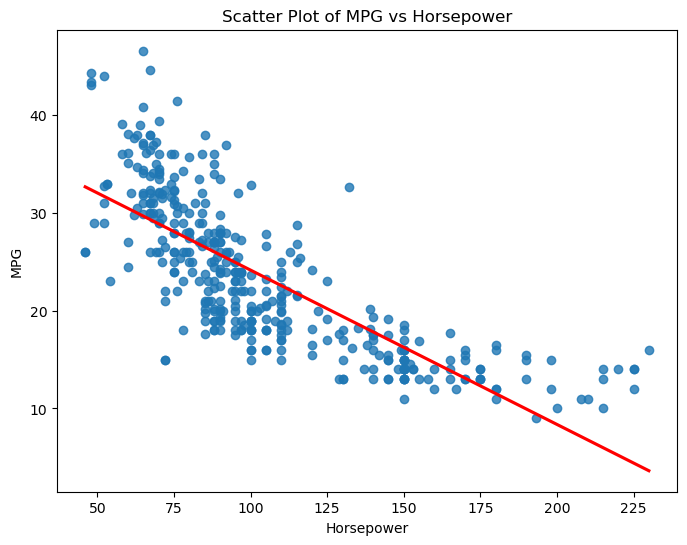

```python
# Scatter plot with linear regression line
import matplotlib.pyplot as plt
import seaborn as sns

plt.figure(figsize=(8,6))
#plt.scatter(auto_data['horsepower'], auto_data['mpg'], alpha=0.6)
sns.regplot(x='horsepower', y='mpg', data=auto_data, ci=None, line_kws={'color': 'red'})
plt.xlabel('Horsepower')
plt.ylabel('MPG')
plt.title('Scatter Plot of MPG vs Horsepower')
plt.show()
```

```python
# Alternative Solution: if using only matplotlib
#import matplotlib.pyplot as plt
#import numpy as np

#intercept = model.params['Intercept']
#slope = model.params['horsepower']
# Use the min and max horsepower to plot the line
#x = np.linspace(auto_data['horsepower'].min(), auto_data['horsepower'].max(), 100)
#y = intercept + slope * x

#plt.figure(figsize=(8,6))
#plt.scatter(auto_data['horsepower'], auto_data['mpg'], alpha=0.6)
#plt.plot(x, y, color='red', linewidth=2)  # regression line
#plt.xlabel('Horsepower')
#plt.ylabel('MPG')
#plt.title('MPG vs Horsepower with Regression Line')
#plt.show()
```

f) By looking at the scatter plot, it appears that the relationship between the predictor and the response is not linear. Produce some diagnostic plots of the least squares regression fit. Comment on any problems you see with the fit. If the relationship is linear, the Residuals vs Fitted plot should show no strong pattern.

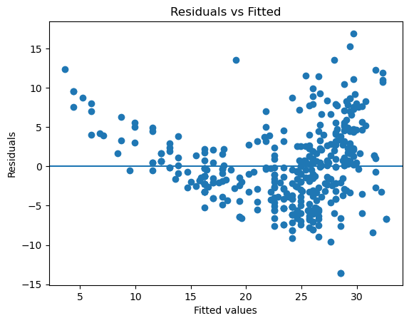

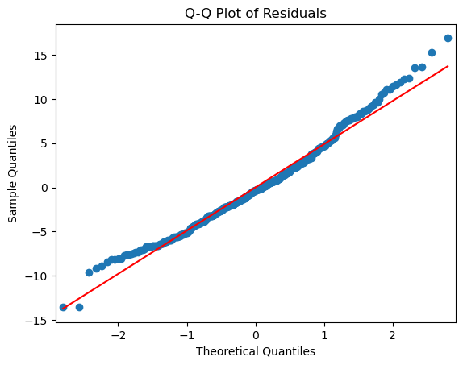

```python
import matplotlib.pyplot as plt
import statsmodels.api as sm
# -----------------------------
# 1. Residuals vs Fitted
# -----------------------------
plt.figure()
plt.scatter(model.fittedvalues, model.resid)
plt.axhline(0)
plt.xlabel("Fitted values")
plt.ylabel("Residuals")
plt.title("Residuals vs Fitted")
plt.show()

# -----------------------------
# 2. Q-Q Plot of Residuals
# -----------------------------
sm.qqplot(model.resid, line='s')
plt.title("Q-Q Plot of Residuals")
plt.show()
```

To implement this in statsmodels.formula.api, apply a transformation to the predictor and wrap within the I()function (e.g. I(predictor^2)) and treat it like a normal predictor variable. Generate a new model (model2) and interpret whether including the squared term improves the fit.

```python
model2 = smf.ols('mpg ~ horsepower + I(horsepower**2)', data=auto_data).fit()
print(model2.summary())

# The fit appears to be substantially better than the fit obtained when just the linear term is included. The adjusted R2 of the quadratic fit is 0.686, compared to
# 0.606 for the linear fit, and the p-value for the quadratic term is highly significant
# The quadratic model provides a better fit than the linear model, increasing the explained variance (R2) to 68.8%.
```

```
                            OLS Regression Results
==============================================================================
Dep. Variable:                    mpg   R-squared:                       0.688
Model:                            OLS   Adj. R-squared:                  0.686
Method:                 Least Squares   F-statistic:                     428.0
Date:                Mon, 12 Jan 2026   Prob (F-statistic):           5.40e-99
Time:                        21:36:40   Log-Likelihood:                -1133.2
No. Observations:                 392   AIC:                             2272.
Df Residuals:                     389   BIC:                             2284.
Df Model:                           2
Covariance Type:            nonrobust
======================================================================================
                         coef    std err          t      P>|t|      [0.025      0.975]
--------------------------------------------------------------------------------------
Intercept             56.9001      1.800     31.604      0.000      53.360      60.440
horsepower            -0.4662      0.031    -14.978      0.000      -0.527      -0.405
I(horsepower ** 2)     0.0012      0.000     10.080      0.000       0.001       0.001
==============================================================================
Omnibus:                       16.158   Durbin-Watson:                   1.090
Prob(Omnibus):                  0.000   Jarque-Bera (JB):               30.662
Skew:                           0.218   Prob(JB):                     2.20e-07
Kurtosis:                       4.299   Cond. No.                     1.29e+05
==============================================================================

Notes:
[1] Standard Errors assume that the covariance matrix of the errors is correctly specified.
[2] The condition number is large, 1.29e+05. This might indicate that there are
strong multicollinearity or other numerical problems.
```

Demostration The curve for model2 can be added to the scatter plot by executing the following:

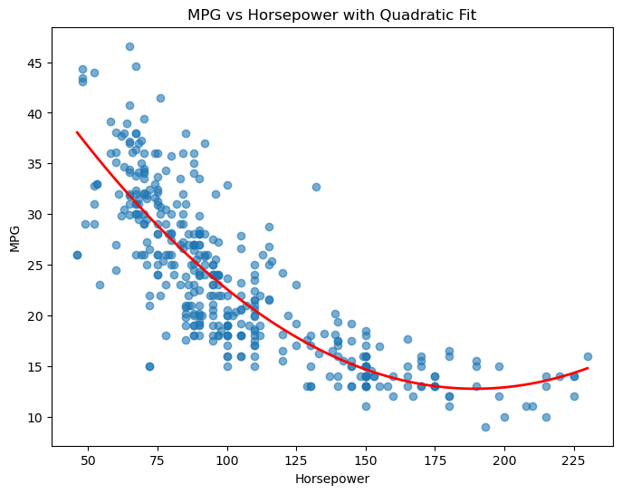

```python
import numpy as np
import matplotlib.pyplot as plt
import seaborn as sns

# Scatter plot of the data
plt.figure(figsize=(8,6))
plt.scatter(auto_data['horsepower'], auto_data['mpg'], alpha=0.6)

# Generate a sequence of x-values (horsepower)
xrange = np.linspace(auto_data['horsepower'].min(), auto_data['horsepower'].max(), 100)

# Predict mpg using model2 for these x-values
y_pred = model2.predict(pd.DataFrame({'horsepower': xrange, 'I(horsepower ** 2)': xrange**2}))

# Plot the quadratic regression curve
plt.plot(xrange, y_pred, color='red', linewidth=2)

plt.xlabel('Horsepower')
plt.ylabel('MPG')
plt.title('MPG vs Horsepower with Quadratic Fit')
plt.show()
```

i) Generate diagnostic plots for model2 and examine the residuals versus fitted plot How does it differ from the residual plot of the simple linear model?

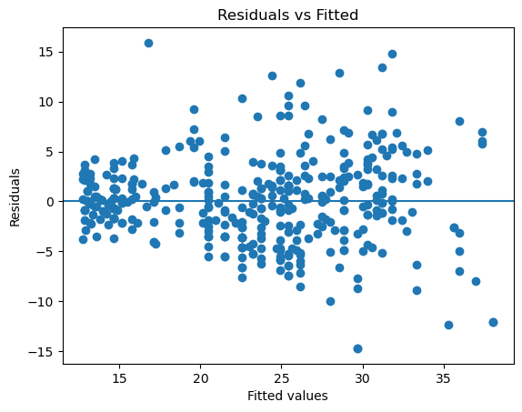

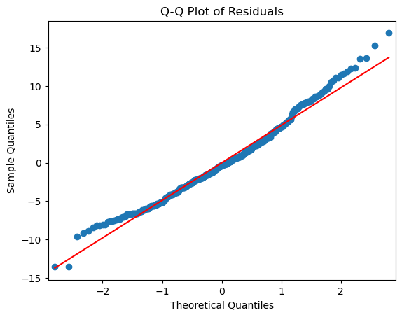

```python
# -----------------------------
# 1. Residuals vs Fitted
# -----------------------------
plt.figure()
plt.scatter(model2.fittedvalues, model2.resid)
plt.axhline(0)
plt.xlabel("Fitted values")
plt.ylabel("Residuals")
plt.title("Residuals vs Fitted")
plt.show()

# -----------------------------
# 2. Q-Q Plot of Residuals
# -----------------------------
sm.qqplot(model.resid, line='s')
plt.title("Q-Q Plot of Residuals")
plt.show()
```

```python
# We exclude 'name' as it is a qualitative string variable
formula = 'mpg ~ cylinders + displacement + horsepower + weight + acceleration + year'

# Fit the Multiple Linear Regression model
mlr_model = smf.ols(formula, data=auto_data).fit()

# Print the summary results
print(mlr_model.summary())
```

```
                            OLS Regression Results
==============================================================================
Dep. Variable:                    mpg   R-squared:                       0.809
Model:                            OLS   Adj. R-squared:                  0.806
Method:                 Least Squares   F-statistic:                     272.2
Date:                Mon, 12 Jan 2026   Prob (F-statistic):          3.79e-135
Time:                        21:44:19   Log-Likelihood:                -1036.5
No. Observations:                 392   AIC:                             2087.
Df Residuals:                     385   BIC:                             2115.
Df Model:                           6
Covariance Type:            nonrobust
================================================================================
                   coef    std err          t      P>|t|      [0.025      0.975]
--------------------------------------------------------------------------------
Intercept      -14.5353      4.764     -3.051      0.002     -23.902      -5.169
cylinders       -0.3299      0.332     -0.993      0.321      -0.983       0.323
displacement     0.0077      0.007      1.044      0.297      -0.007       0.022
horsepower      -0.0004      0.014     -0.028      0.977      -0.028       0.027
weight          -0.0068      0.001    -10.141      0.000      -0.008      -0.005
acceleration     0.0853      0.102      0.836      0.404      -0.115       0.286
year             0.7534      0.053     14.318      0.000       0.650       0.857
==============================================================================
Omnibus:                       37.865   Durbin-Watson:                   1.296
Prob(Omnibus):                  0.000   Jarque-Bera (JB):               60.248
Skew:                           0.630   Prob(JB):                     8.26e-14
Kurtosis:                       4.449   Cond. No.                     8.53e+04
==============================================================================

Notes:
[1] Standard Errors assume that the covariance matrix of the errors is correctly specified.
[2] The condition number is large, 8.53e+04. This might indicate that there are
strong multicollinearity or other numerical problems.
```